# IE6400 Foundations for Data Analytics Engineering

# Fall 2023

### Module 2: Exploratory Data Analysis (EDA)

### Case Study - Diamond Dataset

In this exercise, we will read from a dataset. The example here uses the diamonds dataset:

```python
#Load pandas library
import pandas as pd

diamonds_df = pd.read_csv('diamonds.csv')

diamonds_df
```

|  | carat | cut | color | clarity | depth | table | price | x | y | z |
| --- | --- | --- | --- | --- | --- | --- | --- | --- | --- | --- |
| 0 | 0.23 | Ideal | E | SI2 | 61.5 | 55.0 | 326 | 3.95 | 3.98 | 2.43 |
| 1 | 0.21 | Premium | E | SI1 | 59.8 | 61.0 | 326 | 3.89 | 3.84 | 2.31 |
| 2 | 0.23 | Good | E | VS1 | 56.9 | 65.0 | 327 | 4.05 | 4.07 | 2.31 |
| 3 | 0.29 | Premium | I | VS2 | 62.4 | 58.0 | 334 | 4.20 | 4.23 | 2.63 |
| 4 | 0.31 | Good | J | SI2 | 63.3 | 58.0 | 335 | 4.34 | 4.35 | 2.75 |
| ... | ... | ... | ... | ... | ... | ... | ... | ... | ... | ... |
| 53935 | 0.72 | Ideal | D | SI1 | 60.8 | 57.0 | 2757 | 5.75 | 5.76 | 3.50 |
| 53936 | 0.72 | Good | D | SI1 | 63.1 | 55.0 | 2757 | 5.69 | 5.75 | 3.61 |
| 53937 | 0.70 | Very Good | D | SI1 | 62.8 | 60.0 | 2757 | 5.66 | 5.68 | 3.56 |
| 53938 | 0.86 | Premium | H | SI2 | 61.0 | 58.0 | 2757 | 6.15 | 6.12 | 3.74 |
| 53939 | 0.75 | Ideal | D | SI2 | 62.2 | 55.0 | 2757 | 5.83 | 5.87 | 3.64 |

53940 rows × 10 columns

Count the number of rows and columns in the DataFrame using the shape function:

```python
diamonds_df.shape
```

```
(53940, 10)
```

Summarize the columns using describe() to obtain the distribution of variables, including mean, median, min, max, and the different quartiles:

```python
diamonds_df.describe()
```

|  | carat | depth | table | price | x | y | z |
| --- | --- | --- | --- | --- | --- | --- | --- |
| count | 53940.000000 | 53940.000000 | 53940.000000 | 53940.000000 | 53940.000000 | 53940.000000 | 53940.000000 |
| mean | 0.797940 | 61.749405 | 57.457184 | 3932.799722 | 5.731157 | 5.734526 | 3.538734 |
| std | 0.474011 | 1.432621 | 2.234491 | 3989.439738 | 1.121761 | 1.142135 | 0.705699 |
| min | 0.200000 | 43.000000 | 43.000000 | 326.000000 | 0.000000 | 0.000000 | 0.000000 |
| 25% | 0.400000 | 61.000000 | 56.000000 | 950.000000 | 4.710000 | 4.720000 | 2.910000 |
| 50% | 0.700000 | 61.800000 | 57.000000 | 2401.000000 | 5.700000 | 5.710000 | 3.530000 |
| 75% | 1.040000 | 62.500000 | 59.000000 | 5324.250000 | 6.540000 | 6.540000 | 4.040000 |
| max | 5.010000 | 79.000000 | 95.000000 | 18823.000000 | 10.740000 | 58.900000 | 31.800000 |

Use include=object inside the describe function for categorical variables ( cut, color, clarity):

```python
diamonds_df.describe(include=object)
```

|  | cut | color | clarity |
| --- | --- | --- | --- |
| count | 53940 | 53940 | 53940 |
| unique | 5 | 7 | 8 |
| top | Ideal | G | SI1 |
| freq | 21551 | 11292 | 13065 |

To obtain information on the dataset, use the info() method:

```python
diamonds_df.info()
```

```
<class 'pandas.core.frame.DataFrame'>
RangeIndex: 53940 entries, 0 to 53939
Data columns (total 10 columns):
 #   Column   Non-Null Count  Dtype
---  ------   --------------  -----
 0   carat    53940 non-null  float64
 1   cut      53940 non-null  object
 2   color    53940 non-null  object
 3   clarity  53940 non-null  object
 4   depth    53940 non-null  float64
 5   table    53940 non-null  float64
 6   price    53940 non-null  int64
 7   x        53940 non-null  float64
 8   y        53940 non-null  float64
 9   z        53940 non-null  float64
dtypes: float64(6), int64(1), object(3)
memory usage: 4.1+ MB
```

The preceding figure shows the data type (float64, object, int64..) of each of the columns, and memory (4.1MB) that the DataFrame occupies. It also tells the number of rows (53940) present in the DataFrame.

we are going to add new columns to the diamonds dataset in the pandas library. We'll start with the simple addition of columns and then move ahead and look into the conditional addition of columns.

Add a price_per_carat column to the DataFrame:

```python
diamonds_df['price_per_carat'] = diamonds_df['price']/diamonds_df['carat']
```

```python
diamonds_df
```

|  | carat | cut | color | clarity | depth | table | price | x | y | z | price_per_carat |
| --- | --- | --- | --- | --- | --- | --- | --- | --- | --- | --- | --- |
| 0 | 0.23 | Ideal | E | SI2 | 61.5 | 55.0 | 326 | 3.95 | 3.98 | 2.43 | 1417.391304 |
| 1 | 0.21 | Premium | E | SI1 | 59.8 | 61.0 | 326 | 3.89 | 3.84 | 2.31 | 1552.380952 |
| 2 | 0.23 | Good | E | VS1 | 56.9 | 65.0 | 327 | 4.05 | 4.07 | 2.31 | 1421.739130 |
| 3 | 0.29 | Premium | I | VS2 | 62.4 | 58.0 | 334 | 4.20 | 4.23 | 2.63 | 1151.724138 |
| 4 | 0.31 | Good | J | SI2 | 63.3 | 58.0 | 335 | 4.34 | 4.35 | 2.75 | 1080.645161 |
| ... | ... | ... | ... | ... | ... | ... | ... | ... | ... | ... | ... |
| 53935 | 0.72 | Ideal | D | SI1 | 60.8 | 57.0 | 2757 | 5.75 | 5.76 | 3.50 | 3829.166667 |
| 53936 | 0.72 | Good | D | SI1 | 63.1 | 55.0 | 2757 | 5.69 | 5.75 | 3.61 | 3829.166667 |
| 53937 | 0.70 | Very Good | D | SI1 | 62.8 | 60.0 | 2757 | 5.66 | 5.68 | 3.56 | 3938.571429 |
| 53938 | 0.86 | Premium | H | SI2 | 61.0 | 58.0 | 2757 | 6.15 | 6.12 | 3.74 | 3205.813953 |
| 53939 | 0.75 | Ideal | D | SI2 | 62.2 | 55.0 | 2757 | 5.83 | 5.87 | 3.64 | 3676.000000 |

53940 rows × 11 columns

Now, we'll look at conditional addition of columns. Let's try and add a column based on the value in price_per_carat, say anything more than 3500 as high (coded as 1) and anything less than 3500 as low (coded as 0).

Use the np.where function from Python's numpy package:

```python
#Import numpy package for linear algebra
import numpy as np
diamonds_df['price_per_carat_is_high'] = np.where(diamonds_df['price_per_carat'] > 3500, 1, 0)

diamonds_df
```

|  | carat | cut | color | clarity | depth | table | price | x | y | z | price_per_carat | price_per_carat_is_high |
| --- | --- | --- | --- | --- | --- | --- | --- | --- | --- | --- | --- | --- |
| 0 | 0.23 | Ideal | E | SI2 | 61.5 | 55.0 | 326 | 3.95 | 3.98 | 2.43 | 1417.391304 | 0 |
| 1 | 0.21 | Premium | E | SI1 | 59.8 | 61.0 | 326 | 3.89 | 3.84 | 2.31 | 1552.380952 | 0 |
| 2 | 0.23 | Good | E | VS1 | 56.9 | 65.0 | 327 | 4.05 | 4.07 | 2.31 | 1421.739130 | 0 |
| 3 | 0.29 | Premium | I | VS2 | 62.4 | 58.0 | 334 | 4.20 | 4.23 | 2.63 | 1151.724138 | 0 |
| 4 | 0.31 | Good | J | SI2 | 63.3 | 58.0 | 335 | 4.34 | 4.35 | 2.75 | 1080.645161 | 0 |
| ... | ... | ... | ... | ... | ... | ... | ... | ... | ... | ... | ... | ... |
| 53935 | 0.72 | Ideal | D | SI1 | 60.8 | 57.0 | 2757 | 5.75 | 5.76 | 3.50 | 3829.166667 | 1 |
| 53936 | 0.72 | Good | D | SI1 | 63.1 | 55.0 | 2757 | 5.69 | 5.75 | 3.61 | 3829.166667 | 1 |
| 53937 | 0.70 | Very Good | D | SI1 | 62.8 | 60.0 | 2757 | 5.66 | 5.68 | 3.56 | 3938.571429 | 1 |
| 53938 | 0.86 | Premium | H | SI2 | 61.0 | 58.0 | 2757 | 6.15 | 6.12 | 3.74 | 3205.813953 | 0 |
| 53939 | 0.75 | Ideal | D | SI2 | 62.2 | 55.0 | 2757 | 5.83 | 5.87 | 3.64 | 3676.000000 | 1 |

53940 rows × 12 columns

Therefore, we have successfully added two new columns to the dataset.

we'll consider a scenario where the price of diamonds has increased and we want to apply an increment factor of 1.3 to the price of all the diamonds in our record.

```python
diamonds_df['price'] = diamonds_df['price'] * 1.3

diamonds_df
```

|  | carat | cut | color | clarity | depth | table | price | x | y | z | price_per_carat | price_per_carat_is_high |
| --- | --- | --- | --- | --- | --- | --- | --- | --- | --- | --- | --- | --- |
| 0 | 0.23 | Ideal | E | SI2 | 61.5 | 55.0 | 423.8 | 3.95 | 3.98 | 2.43 | 1417.391304 | 0 |
| 1 | 0.21 | Premium | E | SI1 | 59.8 | 61.0 | 423.8 | 3.89 | 3.84 | 2.31 | 1552.380952 | 0 |
| 2 | 0.23 | Good | E | VS1 | 56.9 | 65.0 | 425.1 | 4.05 | 4.07 | 2.31 | 1421.739130 | 0 |
| 3 | 0.29 | Premium | I | VS2 | 62.4 | 58.0 | 434.2 | 4.20 | 4.23 | 2.63 | 1151.724138 | 0 |
| 4 | 0.31 | Good | J | SI2 | 63.3 | 58.0 | 435.5 | 4.34 | 4.35 | 2.75 | 1080.645161 | 0 |
| ... | ... | ... | ... | ... | ... | ... | ... | ... | ... | ... | ... | ... |
| 53935 | 0.72 | Ideal | D | SI1 | 60.8 | 57.0 | 3584.1 | 5.75 | 5.76 | 3.50 | 3829.166667 | 1 |
| 53936 | 0.72 | Good | D | SI1 | 63.1 | 55.0 | 3584.1 | 5.69 | 5.75 | 3.61 | 3829.166667 | 1 |
| 53937 | 0.70 | Very Good | D | SI1 | 62.8 | 60.0 | 3584.1 | 5.66 | 5.68 | 3.56 | 3938.571429 | 1 |
| 53938 | 0.86 | Premium | H | SI2 | 61.0 | 58.0 | 3584.1 | 6.15 | 6.12 | 3.74 | 3205.813953 | 0 |
| 53939 | 0.75 | Ideal | D | SI2 | 62.2 | 55.0 | 3584.1 | 5.83 | 5.87 | 3.64 | 3676.000000 | 1 |

53940 rows × 12 columns

Next, we'll round off the price of diamonds to its ceil.

```python
import math

diamonds_df['rounded_price'] = diamonds_df['price'].apply(math.ceil)

diamonds_df
```

|  | carat | cut | color | clarity | depth | table | price | x | y | z | price_per_carat | price_per_carat_is_high | rounded_price |
| --- | --- | --- | --- | --- | --- | --- | --- | --- | --- | --- | --- | --- | --- |
| 0 | 0.23 | Ideal | E | SI2 | 61.5 | 55.0 | 423.8 | 3.95 | 3.98 | 2.43 | 1417.391304 | 0 | 424 |
| 1 | 0.21 | Premium | E | SI1 | 59.8 | 61.0 | 423.8 | 3.89 | 3.84 | 2.31 | 1552.380952 | 0 | 424 |
| 2 | 0.23 | Good | E | VS1 | 56.9 | 65.0 | 425.1 | 4.05 | 4.07 | 2.31 | 1421.739130 | 0 | 426 |
| 3 | 0.29 | Premium | I | VS2 | 62.4 | 58.0 | 434.2 | 4.20 | 4.23 | 2.63 | 1151.724138 | 0 | 435 |
| 4 | 0.31 | Good | J | SI2 | 63.3 | 58.0 | 435.5 | 4.34 | 4.35 | 2.75 | 1080.645161 | 0 | 436 |
| ... | ... | ... | ... | ... | ... | ... | ... | ... | ... | ... | ... | ... | ... |
| 53935 | 0.72 | Ideal | D | SI1 | 60.8 | 57.0 | 3584.1 | 5.75 | 5.76 | 3.50 | 3829.166667 | 1 | 3585 |
| 53936 | 0.72 | Good | D | SI1 | 63.1 | 55.0 | 3584.1 | 5.69 | 5.75 | 3.61 | 3829.166667 | 1 | 3585 |
| 53937 | 0.70 | Very Good | D | SI1 | 62.8 | 60.0 | 3584.1 | 5.66 | 5.68 | 3.56 | 3938.571429 | 1 | 3585 |
| 53938 | 0.86 | Premium | H | SI2 | 61.0 | 58.0 | 3584.1 | 6.15 | 6.12 | 3.74 | 3205.813953 | 0 | 3585 |
| 53939 | 0.75 | Ideal | D | SI2 | 62.2 | 55.0 | 3584.1 | 5.83 | 5.87 | 3.64 | 3676.000000 | 1 | 3585 |

53940 rows × 13 columns

Next, suppose we are interested in buying diamonds that have an Ideal cut and a color of D (entirely colorless). This exercise is for adding a new column, desired to the DataFrame, whose value will be yes if our criteria are satisfied and no if not satisfied.

```python
# Write a function to determine whether a record, x, is desired or not:

def is_desired(x):
    bool_var = 'yes' if (x['cut']=='Ideal' and x['color']=='D') else 'no'
    return bool_var
```

Use the apply function to add the new column, desired:

```python
diamonds_df['desired'] = diamonds_df.apply(is_desired, axis=1)

diamonds_df
```

|  | carat | cut | color | clarity | depth | table | price | x | y | z | price_per_carat | price_per_carat_is_high | rounded_price | desired |
| --- | --- | --- | --- | --- | --- | --- | --- | --- | --- | --- | --- | --- | --- | --- |
| 0 | 0.23 | Ideal | E | SI2 | 61.5 | 55.0 | 423.8 | 3.95 | 3.98 | 2.43 | 1417.391304 | 0 | 424 | no |
| 1 | 0.21 | Premium | E | SI1 | 59.8 | 61.0 | 423.8 | 3.89 | 3.84 | 2.31 | 1552.380952 | 0 | 424 | no |
| 2 | 0.23 | Good | E | VS1 | 56.9 | 65.0 | 425.1 | 4.05 | 4.07 | 2.31 | 1421.739130 | 0 | 426 | no |
| 3 | 0.29 | Premium | I | VS2 | 62.4 | 58.0 | 434.2 | 4.20 | 4.23 | 2.63 | 1151.724138 | 0 | 435 | no |
| 4 | 0.31 | Good | J | SI2 | 63.3 | 58.0 | 435.5 | 4.34 | 4.35 | 2.75 | 1080.645161 | 0 | 436 | no |
| ... | ... | ... | ... | ... | ... | ... | ... | ... | ... | ... | ... | ... | ... | ... |
| 53935 | 0.72 | Ideal | D | SI1 | 60.8 | 57.0 | 3584.1 | 5.75 | 5.76 | 3.50 | 3829.166667 | 1 | 3585 | yes |
| 53936 | 0.72 | Good | D | SI1 | 63.1 | 55.0 | 3584.1 | 5.69 | 5.75 | 3.61 | 3829.166667 | 1 | 3585 | no |
| 53937 | 0.70 | Very Good | D | SI1 | 62.8 | 60.0 | 3584.1 | 5.66 | 5.68 | 3.56 | 3938.571429 | 1 | 3585 | no |
| 53938 | 0.86 | Premium | H | SI2 | 61.0 | 58.0 | 3584.1 | 6.15 | 6.12 | 3.74 | 3205.813953 | 0 | 3585 | no |
| 53939 | 0.75 | Ideal | D | SI2 | 62.2 | 55.0 | 3584.1 | 5.83 | 5.87 | 3.64 | 3676.000000 | 1 | 3585 | yes |

53940 rows × 14 columns

The new column desired is added!

The last thing to do is write a DataFrame to a file. We will be using the to_csv() function.

```python
diamonds_df.to_csv('diamonds_modified.csv')
```

Plot a histogram using the diamonds dataset where x axis = carat:

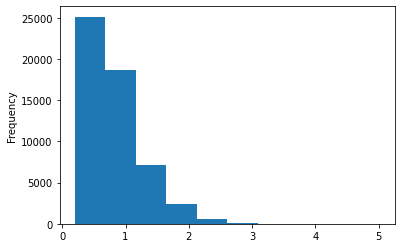

```python
import matplotlib.pyplot as plt

diamonds_df.carat.plot.hist(orientation = 'vertical')
plt.show()
```

Revised Date: September 30, 2023